# Risk Factor Analysis

## Outcome Variable

**Outcome Variable:** ever_swasted

## Predictor Variables

**Intervention Variable:** feducyrs

**Adjustment Set:**

- arm
- W_mage
- meducyrs
- hhwealth_quart
- W_mhtcm
- W_mwtkg
- W_mbmi
- W_gagebrth
- W_birthwt
- W_birthlen
- single
- delta_W_mage
- delta_meducyrs
- delta_hhwealth_quart
- delta_W_mhtcm
- delta_W_mwtkg
- delta_W_mbmi
- delta_W_gagebrth
- delta_W_birthwt
- delta_W_birthlen
- delta_single

## Stratifying Variables

The analysis was stratified on these variable(s):

- agecat
- studyid
- country

## Data Summary

| agecat | studyid | country | feducyrs | ever_swasted | n_cell | n |
| --- | --- | --- | --- | --- | --- | --- |
| 0-24 months | ki0047075b-MAL-ED | BANGLADESH | High | 0 | 50 | 147 |
| 0-24 months | ki0047075b-MAL-ED | BANGLADESH | High | 1 | 4 | 147 |
| 0-24 months | ki0047075b-MAL-ED | BANGLADESH | Low | 0 | 33 | 147 |
| 0-24 months | ki0047075b-MAL-ED | BANGLADESH | Low | 1 | 6 | 147 |
| 0-24 months | ki0047075b-MAL-ED | BANGLADESH | Medium | 0 | 49 | 147 |
| 0-24 months | ki0047075b-MAL-ED | BANGLADESH | Medium | 1 | 5 | 147 |
| 0-24 months | ki0047075b-MAL-ED | INDIA | High | 0 | 43 | 147 |
| 0-24 months | ki0047075b-MAL-ED | INDIA | High | 1 | 1 | 147 |
| 0-24 months | ki0047075b-MAL-ED | INDIA | Low | 0 | 51 | 147 |
| 0-24 months | ki0047075b-MAL-ED | INDIA | Low | 1 | 8 | 147 |
| 0-24 months | ki0047075b-MAL-ED | INDIA | Medium | 0 | 37 | 147 |
| 0-24 months | ki0047075b-MAL-ED | INDIA | Medium | 1 | 7 | 147 |
| 0-24 months | ki0047075b-MAL-ED | NEPAL | High | 0 | 40 | 98 |
| 0-24 months | ki0047075b-MAL-ED | NEPAL | High | 1 | 2 | 98 |
| 0-24 months | ki0047075b-MAL-ED | NEPAL | Low | 0 | 28 | 98 |
| 0-24 months | ki0047075b-MAL-ED | NEPAL | Low | 1 | 0 | 98 |
| 0-24 months | ki0047075b-MAL-ED | NEPAL | Medium | 0 | 26 | 98 |
| 0-24 months | ki0047075b-MAL-ED | NEPAL | Medium | 1 | 2 | 98 |
| 0-24 months | ki0047075b-MAL-ED | PERU | High | 0 | 116 | 250 |
| 0-24 months | ki0047075b-MAL-ED | PERU | High | 1 | 4 | 250 |
| 0-24 months | ki0047075b-MAL-ED | PERU | Low | 0 | 69 | 250 |
| 0-24 months | ki0047075b-MAL-ED | PERU | Low | 1 | 0 | 250 |
| 0-24 months | ki0047075b-MAL-ED | PERU | Medium | 0 | 61 | 250 |
| 0-24 months | ki0047075b-MAL-ED | PERU | Medium | 1 | 0 | 250 |
| 0-24 months | ki0047075b-MAL-ED | SOUTH AFRICA | High | 0 | 43 | 110 |
| 0-24 months | ki0047075b-MAL-ED | SOUTH AFRICA | High | 1 | 0 | 110 |
| 0-24 months | ki0047075b-MAL-ED | SOUTH AFRICA | Low | 0 | 32 | 110 |
| 0-24 months | ki0047075b-MAL-ED | SOUTH AFRICA | Low | 1 | 5 | 110 |
| 0-24 months | ki0047075b-MAL-ED | SOUTH AFRICA | Medium | 0 | 30 | 110 |
| 0-24 months | ki0047075b-MAL-ED | SOUTH AFRICA | Medium | 1 | 0 | 110 |

[output cut: 330 more lines]

The following strata were considered:

- agecat: 0-24 months, studyid: ki0047075b-MAL-ED, country: BANGLADESH
- agecat: 0-24 months, studyid: ki0047075b-MAL-ED, country: INDIA
- agecat: 0-24 months, studyid: ki0047075b-MAL-ED, country: NEPAL
- agecat: 0-24 months, studyid: ki0047075b-MAL-ED, country: PERU
- agecat: 0-24 months, studyid: ki0047075b-MAL-ED, country: SOUTH AFRICA
- agecat: 0-24 months, studyid: ki0047075b-MAL-ED, country: TANZANIA, UNITED REPUBLIC OF
- agecat: 0-24 months, studyid: ki1000304b-SAS-CompFeed, country: INDIA
- agecat: 0-24 months, studyid: ki1000304b-SAS-FoodSuppl, country: INDIA
- agecat: 0-24 months, studyid: ki1017093b-PROVIDE, country: BANGLADESH
- agecat: 0-24 months, studyid: ki1017093c-NIH-Crypto, country: BANGLADESH
- agecat: 0-24 months, studyid: ki1066203-TanzaniaChild2, country: TANZANIA, UNITED REPUBLIC OF
- agecat: 0-24 months, studyid: ki1113344-GMS-Nepal, country: NEPAL
- agecat: 0-24 months, studyid: ki1119695-PROBIT, country: BELARUS
- agecat: 0-24 months, studyid: ki1126311-ZVITAMBO, country: ZIMBABWE
- agecat: 0-24 months, studyid: ki1135781-COHORTS, country: GUATEMALA
- agecat: 0-24 months, studyid: ki1135781-COHORTS, country: INDIA
- agecat: 0-24 months, studyid: ki1135781-COHORTS, country: PHILIPPINES
- agecat: 0-24 months, studyid: ki1148112-LCNI-5, country: MALAWI
- agecat: 0-24 months, studyid: kiGH5241-JiVitA-3, country: BANGLADESH
- agecat: 0-24 months, studyid: kiGH5241-JiVitA-4, country: BANGLADESH
- agecat: 0-6 months, studyid: ki0047075b-MAL-ED, country: BANGLADESH
- agecat: 0-6 months, studyid: ki0047075b-MAL-ED, country: INDIA
- agecat: 0-6 months, studyid: ki0047075b-MAL-ED, country: NEPAL
- agecat: 0-6 months, studyid: ki0047075b-MAL-ED, country: PERU
- agecat: 0-6 months, studyid: ki0047075b-MAL-ED, country: SOUTH AFRICA
- agecat: 0-6 months, studyid: ki0047075b-MAL-ED, country: TANZANIA, UNITED REPUBLIC OF
- agecat: 0-6 months, studyid: ki1000304b-SAS-CompFeed, country: INDIA
- agecat: 0-6 months, studyid: ki1000304b-SAS-FoodSuppl, country: INDIA
- agecat: 0-6 months, studyid: ki1017093b-PROVIDE, country: BANGLADESH
- agecat: 0-6 months, studyid: ki1017093c-NIH-Crypto, country: BANGLADESH
- agecat: 0-6 months, studyid: ki1066203-TanzaniaChild2, country: TANZANIA, UNITED REPUBLIC OF
- agecat: 0-6 months, studyid: ki1113344-GMS-Nepal, country: NEPAL
- agecat: 0-6 months, studyid: ki1119695-PROBIT, country: BELARUS
- agecat: 0-6 months, studyid: ki1126311-ZVITAMBO, country: ZIMBABWE
- agecat: 0-6 months, studyid: ki1135781-COHORTS, country: GUATEMALA
- agecat: 0-6 months, studyid: ki1135781-COHORTS, country: INDIA
- agecat: 0-6 months, studyid: ki1135781-COHORTS, country: PHILIPPINES
- agecat: 0-6 months, studyid: ki1148112-LCNI-5, country: MALAWI
- agecat: 0-6 months, studyid: kiGH5241-JiVitA-3, country: BANGLADESH
- agecat: 0-6 months, studyid: kiGH5241-JiVitA-4, country: BANGLADESH
- agecat: 6-24 months, studyid: ki0047075b-MAL-ED, country: BANGLADESH
- agecat: 6-24 months, studyid: ki0047075b-MAL-ED, country: INDIA
- agecat: 6-24 months, studyid: ki0047075b-MAL-ED, country: NEPAL
- agecat: 6-24 months, studyid: ki0047075b-MAL-ED, country: PERU
- agecat: 6-24 months, studyid: ki0047075b-MAL-ED, country: SOUTH AFRICA
- agecat: 6-24 months, studyid: ki0047075b-MAL-ED, country: TANZANIA, UNITED REPUBLIC OF
- agecat: 6-24 months, studyid: ki1000304b-SAS-CompFeed, country: INDIA
- agecat: 6-24 months, studyid: ki1000304b-SAS-FoodSuppl, country: INDIA
- agecat: 6-24 months, studyid: ki1017093b-PROVIDE, country: BANGLADESH
- agecat: 6-24 months, studyid: ki1017093c-NIH-Crypto, country: BANGLADESH
- agecat: 6-24 months, studyid: ki1066203-TanzaniaChild2, country: TANZANIA, UNITED REPUBLIC OF
- agecat: 6-24 months, studyid: ki1113344-GMS-Nepal, country: NEPAL
- agecat: 6-24 months, studyid: ki1119695-PROBIT, country: BELARUS
- agecat: 6-24 months, studyid: ki1126311-ZVITAMBO, country: ZIMBABWE
- agecat: 6-24 months, studyid: ki1135781-COHORTS, country: GUATEMALA
- agecat: 6-24 months, studyid: ki1135781-COHORTS, country: INDIA
- agecat: 6-24 months, studyid: ki1135781-COHORTS, country: PHILIPPINES
- agecat: 6-24 months, studyid: ki1148112-LCNI-5, country: MALAWI
- agecat: 6-24 months, studyid: kiGH5241-JiVitA-3, country: BANGLADESH
- agecat: 6-24 months, studyid: kiGH5241-JiVitA-4, country: BANGLADESH

### Dropped Strata

Some strata were dropped due to rare outcomes:

- agecat: 0-24 months, studyid: ki0047075b-MAL-ED, country: BANGLADESH
- agecat: 0-24 months, studyid: ki0047075b-MAL-ED, country: INDIA
- agecat: 0-24 months, studyid: ki0047075b-MAL-ED, country: NEPAL
- agecat: 0-24 months, studyid: ki0047075b-MAL-ED, country: PERU
- agecat: 0-24 months, studyid: ki0047075b-MAL-ED, country: SOUTH AFRICA
- agecat: 0-24 months, studyid: ki0047075b-MAL-ED, country: TANZANIA, UNITED REPUBLIC OF
- agecat: 0-24 months, studyid: ki1148112-LCNI-5, country: MALAWI
- agecat: 0-6 months, studyid: ki0047075b-MAL-ED, country: BANGLADESH
- agecat: 0-6 months, studyid: ki0047075b-MAL-ED, country: INDIA
- agecat: 0-6 months, studyid: ki0047075b-MAL-ED, country: NEPAL
- agecat: 0-6 months, studyid: ki0047075b-MAL-ED, country: PERU
- agecat: 0-6 months, studyid: ki0047075b-MAL-ED, country: SOUTH AFRICA
- agecat: 0-6 months, studyid: ki0047075b-MAL-ED, country: TANZANIA, UNITED REPUBLIC OF
- agecat: 0-6 months, studyid: ki1148112-LCNI-5, country: MALAWI
- agecat: 6-24 months, studyid: ki0047075b-MAL-ED, country: BANGLADESH
- agecat: 6-24 months, studyid: ki0047075b-MAL-ED, country: INDIA
- agecat: 6-24 months, studyid: ki0047075b-MAL-ED, country: NEPAL
- agecat: 6-24 months, studyid: ki0047075b-MAL-ED, country: PERU
- agecat: 6-24 months, studyid: ki0047075b-MAL-ED, country: SOUTH AFRICA
- agecat: 6-24 months, studyid: ki0047075b-MAL-ED, country: TANZANIA, UNITED REPUBLIC OF
- agecat: 6-24 months, studyid: ki1017093b-PROVIDE, country: BANGLADESH
- agecat: 6-24 months, studyid: ki1017093c-NIH-Crypto, country: BANGLADESH
- agecat: 6-24 months, studyid: ki1119695-PROBIT, country: BELARUS
- agecat: 6-24 months, studyid: ki1148112-LCNI-5, country: MALAWI

## Methods Detail

We’re interested in the causal parameters $E[Y_a]$ for all values of $a \in \mathcal{A}$. These parameters represent the mean outcome if, possibly contrary to fact, we intervened to set all units to have $A=a$. Under the randomization and positivity assumptions, these are identified by the statistical parameters $\psi_a=E_W[E_{Y|A,W}(Y|A=a,W)]$. In addition, we’re interested in the mean of $Y$, $E[Y]$ under no intervention (the observed mean). We will estimate these parameters by using SuperLearner to fit the relevant likelihood factors – $E_{Y|A,W}(Y|A=a,W)$ and $p(A=a|W)$, and then updating our likelihood fit using a joint TMLE.

For unadjusted analyses ($W=\{\}$), initial likelihoods were estimated using Lrnr_glm to estimate the simple $E(Y|A)$ and Lrnr_mean to estimate $p(A)$. For adjusted analyses, a small library containing Lrnr_glmnet, Lrnr_xgboost, and Lrnr_mean was used.

Having estimated these parameters, we will then use the delta method to estimate relative risks and attributable risks relative to a prespecified baseline level of $A$.

# Results Detail

## Results Plots

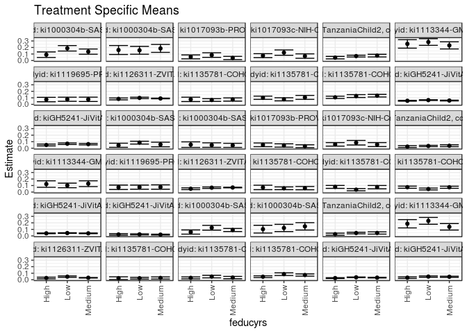

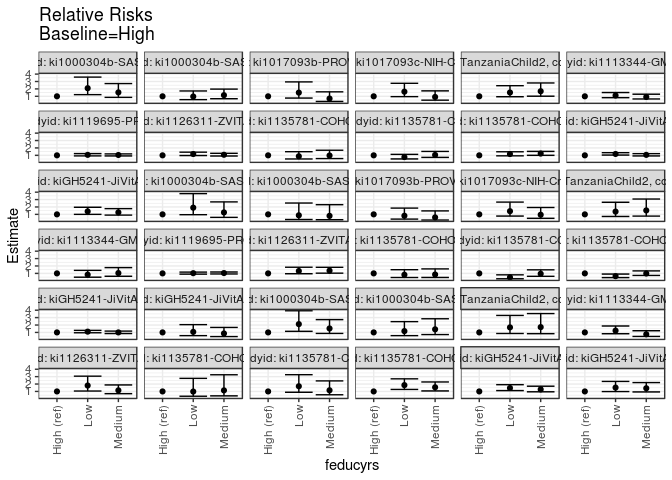

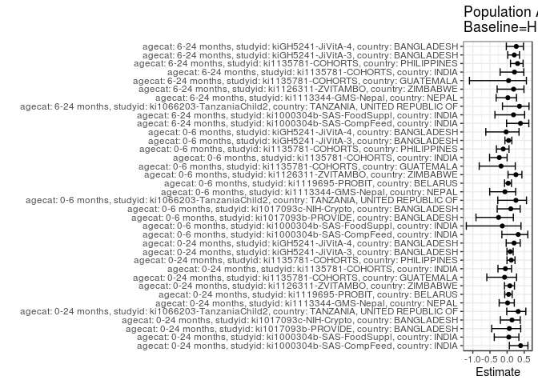

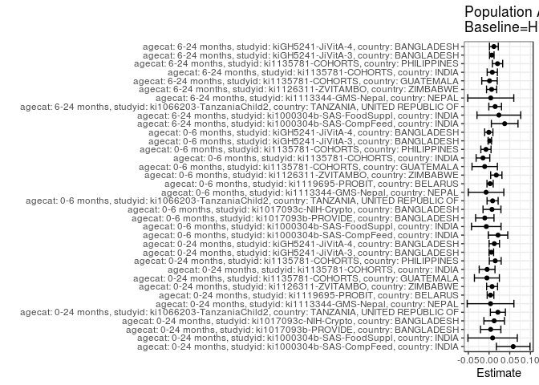

## Results Table

### Parameter: TSM

| agecat | studyid | country | intervention_level | baseline_level | estimate | ci_lower | ci_upper |
| --- | --- | --- | --- | --- | --- | --- | --- |
| 0-24 months | ki1000304b-SAS-CompFeed | INDIA | High | NA | 0.0893430 | 0.0470145 | 0.1316715 |
| 0-24 months | ki1000304b-SAS-CompFeed | INDIA | Low | NA | 0.1874065 | 0.1455511 | 0.2292620 |
| 0-24 months | ki1000304b-SAS-CompFeed | INDIA | Medium | NA | 0.1366755 | 0.0967674 | 0.1765836 |
| 0-24 months | ki1000304b-SAS-FoodSuppl | INDIA | High | NA | 0.1612536 | 0.0927412 | 0.2297661 |
| 0-24 months | ki1000304b-SAS-FoodSuppl | INDIA | Low | NA | 0.1572068 | 0.0968251 | 0.2175884 |
| 0-24 months | ki1000304b-SAS-FoodSuppl | INDIA | Medium | NA | 0.1858570 | 0.1248521 | 0.2468619 |
| 0-24 months | ki1017093b-PROVIDE | BANGLADESH | High | NA | 0.0560345 | 0.0264189 | 0.0856501 |
| 0-24 months | ki1017093b-PROVIDE | BANGLADESH | Low | NA | 0.0840336 | 0.0487611 | 0.1193061 |
| 0-24 months | ki1017093b-PROVIDE | BANGLADESH | Medium | NA | 0.0391304 | 0.0140529 | 0.0642079 |
| 0-24 months | ki1017093c-NIH-Crypto | BANGLADESH | High | NA | 0.0747005 | 0.0443799 | 0.1050211 |
| 0-24 months | ki1017093c-NIH-Crypto | BANGLADESH | Low | NA | 0.1214740 | 0.0803419 | 0.1626060 |
| 0-24 months | ki1017093c-NIH-Crypto | BANGLADESH | Medium | NA | 0.0680558 | 0.0339951 | 0.1021166 |
| 0-24 months | ki1066203-TanzaniaChild2 | TANZANIA, UNITED REPUBLIC OF | High | NA | 0.0445668 | 0.0254695 | 0.0636641 |
| 0-24 months | ki1066203-TanzaniaChild2 | TANZANIA, UNITED REPUBLIC OF | Low | NA | 0.0675440 | 0.0537894 | 0.0812987 |
| 0-24 months | ki1066203-TanzaniaChild2 | TANZANIA, UNITED REPUBLIC OF | Medium | NA | 0.0752009 | 0.0548654 | 0.0955365 |
| 0-24 months | ki1113344-GMS-Nepal | NEPAL | High | NA | 0.2551872 | 0.1896204 | 0.3207541 |
| 0-24 months | ki1113344-GMS-Nepal | NEPAL | Low | NA | 0.2834718 | 0.2329457 | 0.3339978 |
| 0-24 months | ki1113344-GMS-Nepal | NEPAL | Medium | NA | 0.2321152 | 0.1773510 | 0.2868795 |
| 0-24 months | ki1119695-PROBIT | BELARUS | High | NA | 0.0737458 | 0.0396107 | 0.1078809 |
| 0-24 months | ki1119695-PROBIT | BELARUS | Low | NA | 0.0787225 | 0.0473072 | 0.1101377 |
| 0-24 months | ki1119695-PROBIT | BELARUS | Medium | NA | 0.0772681 | 0.0439331 | 0.1106030 |
| 0-24 months | ki1126311-ZVITAMBO | ZIMBABWE | High | NA | 0.0838726 | 0.0699008 | 0.0978444 |
| 0-24 months | ki1126311-ZVITAMBO | ZIMBABWE | Low | NA | 0.0990045 | 0.0881091 | 0.1098999 |
| 0-24 months | ki1126311-ZVITAMBO | ZIMBABWE | Medium | NA | 0.0903850 | 0.0851464 | 0.0956237 |
| 0-24 months | ki1135781-COHORTS | GUATEMALA | High | NA | 0.0765589 | 0.0429992 | 0.1101185 |
| 0-24 months | ki1135781-COHORTS | GUATEMALA | Low | NA | 0.0669854 | 0.0464268 | 0.0875439 |
| 0-24 months | ki1135781-COHORTS | GUATEMALA | Medium | NA | 0.0747847 | 0.0500881 | 0.0994813 |
| 0-24 months | ki1135781-COHORTS | INDIA | High | NA | 0.1015006 | 0.0766818 | 0.1263194 |
| 0-24 months | ki1135781-COHORTS | INDIA | Low | NA | 0.0774994 | 0.0535067 | 0.1014921 |
| 0-24 months | ki1135781-COHORTS | INDIA | Medium | NA | 0.1066539 | 0.0765226 | 0.1367852 |

[output cut: 78 more lines]

### Parameter: E(Y)

| agecat | studyid | country | intervention_level | baseline_level | estimate | ci_lower | ci_upper |
| --- | --- | --- | --- | --- | --- | --- | --- |
| 0-24 months | ki1000304b-SAS-CompFeed | INDIA | NA | NA | 0.1476821 | 0.1188009 | 0.1765633 |
| 0-24 months | ki1000304b-SAS-FoodSuppl | INDIA | NA | NA | 0.1698565 | 0.1338154 | 0.2058975 |
| 0-24 months | ki1017093b-PROVIDE | BANGLADESH | NA | NA | 0.0600000 | 0.0423945 | 0.0776055 |
| 0-24 months | ki1017093c-NIH-Crypto | BANGLADESH | NA | NA | 0.0870712 | 0.0669870 | 0.1071555 |
| 0-24 months | ki1066203-TanzaniaChild2 | TANZANIA, UNITED REPUBLIC OF | NA | NA | 0.0658833 | 0.0559209 | 0.0758458 |
| 0-24 months | ki1113344-GMS-Nepal | NEPAL | NA | NA | 0.2587719 | 0.2259267 | 0.2916172 |
| 0-24 months | ki1119695-PROBIT | BELARUS | NA | NA | 0.0772908 | 0.0449502 | 0.1096314 |
| 0-24 months | ki1126311-ZVITAMBO | ZIMBABWE | NA | NA | 0.0912441 | 0.0863987 | 0.0960895 |
| 0-24 months | ki1135781-COHORTS | GUATEMALA | NA | NA | 0.0713128 | 0.0569485 | 0.0856771 |
| 0-24 months | ki1135781-COHORTS | INDIA | NA | NA | 0.0967519 | 0.0815150 | 0.1119888 |
| 0-24 months | ki1135781-COHORTS | PHILIPPINES | NA | NA | 0.1227336 | 0.1107225 | 0.1347447 |
| 0-24 months | kiGH5241-JiVitA-3 | BANGLADESH | NA | NA | 0.0605314 | 0.0569870 | 0.0640758 |
| 0-24 months | kiGH5241-JiVitA-4 | BANGLADESH | NA | NA | 0.0619670 | 0.0548012 | 0.0691329 |
| 0-6 months | ki1000304b-SAS-CompFeed | INDIA | NA | NA | 0.0665779 | 0.0427569 | 0.0903989 |
| 0-6 months | ki1000304b-SAS-FoodSuppl | INDIA | NA | NA | 0.0478469 | 0.0273607 | 0.0683330 |
| 0-6 months | ki1017093b-PROVIDE | BANGLADESH | NA | NA | 0.0414286 | 0.0266555 | 0.0562017 |
| 0-6 months | ki1017093c-NIH-Crypto | BANGLADESH | NA | NA | 0.0659631 | 0.0482810 | 0.0836451 |
| 0-6 months | ki1066203-TanzaniaChild2 | TANZANIA, UNITED REPUBLIC OF | NA | NA | 0.0331515 | 0.0259618 | 0.0403411 |
| 0-6 months | ki1113344-GMS-Nepal | NEPAL | NA | NA | 0.1154971 | 0.0915268 | 0.1394673 |
| 0-6 months | ki1119695-PROBIT | BELARUS | NA | NA | 0.0758337 | 0.0433525 | 0.1083150 |
| 0-6 months | ki1126311-ZVITAMBO | ZIMBABWE | NA | NA | 0.0681110 | 0.0638575 | 0.0723645 |
| 0-6 months | ki1135781-COHORTS | GUATEMALA | NA | NA | 0.0601805 | 0.0454109 | 0.0749501 |
| 0-6 months | ki1135781-COHORTS | INDIA | NA | NA | 0.0642202 | 0.0514517 | 0.0769887 |
| 0-6 months | ki1135781-COHORTS | PHILIPPINES | NA | NA | 0.0669690 | 0.0578174 | 0.0761205 |
| 0-6 months | kiGH5241-JiVitA-3 | BANGLADESH | NA | NA | 0.0411097 | 0.0380745 | 0.0441448 |
| 0-6 months | kiGH5241-JiVitA-4 | BANGLADESH | NA | NA | 0.0212207 | 0.0163071 | 0.0261342 |
| 6-24 months | ki1000304b-SAS-CompFeed | INDIA | NA | NA | 0.0966811 | 0.0731505 | 0.1202117 |
| 6-24 months | ki1000304b-SAS-FoodSuppl | INDIA | NA | NA | 0.1268657 | 0.0942904 | 0.1594410 |
| 6-24 months | ki1066203-TanzaniaChild2 | TANZANIA, UNITED REPUBLIC OF | NA | NA | 0.0408163 | 0.0321620 | 0.0494707 |
| 6-24 months | ki1113344-GMS-Nepal | NEPAL | NA | NA | 0.1901528 | 0.1584343 | 0.2218713 |
| 6-24 months | ki1126311-ZVITAMBO | ZIMBABWE | NA | NA | 0.0324638 | 0.0290744 | 0.0358532 |
| 6-24 months | ki1135781-COHORTS | GUATEMALA | NA | NA | 0.0248889 | 0.0157815 | 0.0339963 |
| 6-24 months | ki1135781-COHORTS | INDIA | NA | NA | 0.0362989 | 0.0265157 | 0.0460822 |
| 6-24 months | ki1135781-COHORTS | PHILIPPINES | NA | NA | 0.0666667 | 0.0571766 | 0.0761568 |
| 6-24 months | kiGH5241-JiVitA-3 | BANGLADESH | NA | NA | 0.0317355 | 0.0287378 | 0.0347333 |
| 6-24 months | kiGH5241-JiVitA-4 | BANGLADESH | NA | NA | 0.0434288 | 0.0375191 | 0.0493385 |

### Parameter: RR

| agecat | studyid | country | intervention_level | baseline_level | estimate | ci_lower | ci_upper |
| --- | --- | --- | --- | --- | --- | --- | --- |
| 0-24 months | ki1000304b-SAS-CompFeed | INDIA | High | High | 1.0000000 | 1.0000000 | 1.0000000 |
| 0-24 months | ki1000304b-SAS-CompFeed | INDIA | Low | High | 2.0976072 | 1.2247467 | 3.5925437 |
| 0-24 months | ki1000304b-SAS-CompFeed | INDIA | Medium | High | 1.5297842 | 0.8597866 | 2.7218843 |
| 0-24 months | ki1000304b-SAS-FoodSuppl | INDIA | High | High | 1.0000000 | 1.0000000 | 1.0000000 |
| 0-24 months | ki1000304b-SAS-FoodSuppl | INDIA | Low | High | 0.9749040 | 0.5511104 | 1.7245867 |
| 0-24 months | ki1000304b-SAS-FoodSuppl | INDIA | Medium | High | 1.1525760 | 0.6732785 | 1.9730786 |
| 0-24 months | ki1017093b-PROVIDE | BANGLADESH | High | High | 1.0000000 | 1.0000000 | 1.0000000 |
| 0-24 months | ki1017093b-PROVIDE | BANGLADESH | Low | High | 1.4996768 | 0.7636284 | 2.9451898 |
| 0-24 months | ki1017093b-PROVIDE | BANGLADESH | Medium | High | 0.6983278 | 0.3042943 | 1.6025988 |
| 0-24 months | ki1017093c-NIH-Crypto | BANGLADESH | High | High | 1.0000000 | 1.0000000 | 1.0000000 |
| 0-24 months | ki1017093c-NIH-Crypto | BANGLADESH | Low | High | 1.6261466 | 0.9582966 | 2.7594304 |
| 0-24 months | ki1017093c-NIH-Crypto | BANGLADESH | Medium | High | 0.9110491 | 0.4782160 | 1.7356393 |
| 0-24 months | ki1066203-TanzaniaChild2 | TANZANIA, UNITED REPUBLIC OF | High | High | 1.0000000 | 1.0000000 | 1.0000000 |
| 0-24 months | ki1066203-TanzaniaChild2 | TANZANIA, UNITED REPUBLIC OF | Low | High | 1.5155683 | 0.9429685 | 2.4358687 |
| 0-24 months | ki1066203-TanzaniaChild2 | TANZANIA, UNITED REPUBLIC OF | Medium | High | 1.6873758 | 1.0165296 | 2.8009386 |
| 0-24 months | ki1113344-GMS-Nepal | NEPAL | High | High | 1.0000000 | 1.0000000 | 1.0000000 |
| 0-24 months | ki1113344-GMS-Nepal | NEPAL | Low | High | 1.1108383 | 0.8163076 | 1.5116382 |
| 0-24 months | ki1113344-GMS-Nepal | NEPAL | Medium | High | 0.9095879 | 0.6440540 | 1.2845976 |
| 0-24 months | ki1119695-PROBIT | BELARUS | High | High | 1.0000000 | 1.0000000 | 1.0000000 |
| 0-24 months | ki1119695-PROBIT | BELARUS | Low | High | 1.0674844 | 0.9219474 | 1.2359956 |
| 0-24 months | ki1119695-PROBIT | BELARUS | Medium | High | 1.0477628 | 0.9195264 | 1.1938829 |
| 0-24 months | ki1126311-ZVITAMBO | ZIMBABWE | High | High | 1.0000000 | 1.0000000 | 1.0000000 |
| 0-24 months | ki1126311-ZVITAMBO | ZIMBABWE | Low | High | 1.1804157 | 0.9732612 | 1.4316622 |
| 0-24 months | ki1126311-ZVITAMBO | ZIMBABWE | Medium | High | 1.0776468 | 0.9113251 | 1.2743231 |
| 0-24 months | ki1135781-COHORTS | GUATEMALA | High | High | 1.0000000 | 1.0000000 | 1.0000000 |
| 0-24 months | ki1135781-COHORTS | GUATEMALA | Low | High | 0.8749522 | 0.5128685 | 1.4926658 |
| 0-24 months | ki1135781-COHORTS | GUATEMALA | Medium | High | 0.9768263 | 0.5646898 | 1.6897587 |
| 0-24 months | ki1135781-COHORTS | INDIA | High | High | 1.0000000 | 1.0000000 | 1.0000000 |
| 0-24 months | ki1135781-COHORTS | INDIA | Low | High | 0.7635366 | 0.5145473 | 1.1330119 |
| 0-24 months | ki1135781-COHORTS | INDIA | Medium | High | 1.0507713 | 0.7230040 | 1.5271290 |

[output cut: 78 more lines]

### Parameter: PAR

| agecat | studyid | country | intervention_level | baseline_level | estimate | ci_lower | ci_upper |
| --- | --- | --- | --- | --- | --- | --- | --- |
| 0-24 months | ki1000304b-SAS-CompFeed | INDIA | High | NA | 0.0583391 | 0.0177638 | 0.0989145 |
| 0-24 months | ki1000304b-SAS-FoodSuppl | INDIA | High | NA | 0.0086028 | -0.0510377 | 0.0682434 |
| 0-24 months | ki1017093b-PROVIDE | BANGLADESH | High | NA | 0.0039655 | -0.0206446 | 0.0285756 |
| 0-24 months | ki1017093c-NIH-Crypto | BANGLADESH | High | NA | 0.0123707 | -0.0124699 | 0.0372113 |
| 0-24 months | ki1066203-TanzaniaChild2 | TANZANIA, UNITED REPUBLIC OF | High | NA | 0.0213166 | 0.0031968 | 0.0394363 |
| 0-24 months | ki1113344-GMS-Nepal | NEPAL | High | NA | 0.0035847 | -0.0528692 | 0.0600386 |
| 0-24 months | ki1119695-PROBIT | BELARUS | High | NA | 0.0035451 | -0.0045330 | 0.0116231 |
| 0-24 months | ki1126311-ZVITAMBO | ZIMBABWE | High | NA | 0.0073715 | -0.0058421 | 0.0205851 |
| 0-24 months | ki1135781-COHORTS | GUATEMALA | High | NA | -0.0052461 | -0.0353787 | 0.0248865 |
| 0-24 months | ki1135781-COHORTS | INDIA | High | NA | -0.0047487 | -0.0238251 | 0.0143277 |
| 0-24 months | ki1135781-COHORTS | PHILIPPINES | High | NA | 0.0149464 | 0.0006271 | 0.0292658 |
| 0-24 months | kiGH5241-JiVitA-3 | BANGLADESH | High | NA | 0.0055393 | 0.0000484 | 0.0110302 |
| 0-24 months | kiGH5241-JiVitA-4 | BANGLADESH | High | NA | 0.0126365 | 0.0000995 | 0.0251735 |
| 0-6 months | ki1000304b-SAS-CompFeed | INDIA | High | NA | 0.0216546 | -0.0018794 | 0.0451887 |
| 0-6 months | ki1000304b-SAS-FoodSuppl | INDIA | High | NA | -0.0066986 | -0.0424031 | 0.0290059 |
| 0-6 months | ki1017093b-PROVIDE | BANGLADESH | High | NA | -0.0102956 | -0.0324867 | 0.0118956 |
| 0-6 months | ki1017093c-NIH-Crypto | BANGLADESH | High | NA | 0.0070726 | -0.0145830 | 0.0287282 |
| 0-6 months | ki1066203-TanzaniaChild2 | TANZANIA, UNITED REPUBLIC OF | High | NA | 0.0085370 | -0.0048308 | 0.0219048 |
| 0-6 months | ki1113344-GMS-Nepal | NEPAL | High | NA | -0.0072451 | -0.0501877 | 0.0356974 |
| 0-6 months | ki1119695-PROBIT | BELARUS | High | NA | 0.0024689 | -0.0050327 | 0.0099704 |
| 0-6 months | ki1126311-ZVITAMBO | ZIMBABWE | High | NA | 0.0175259 | 0.0038979 | 0.0311540 |
| 0-6 months | ki1135781-COHORTS | GUATEMALA | High | NA | -0.0105226 | -0.0411728 | 0.0201276 |
| 0-6 months | ki1135781-COHORTS | INDIA | High | NA | -0.0147019 | -0.0312456 | 0.0018419 |
| 0-6 months | ki1135781-COHORTS | PHILIPPINES | High | NA | -0.0075143 | -0.0198261 | 0.0047976 |
| 0-6 months | kiGH5241-JiVitA-3 | BANGLADESH | High | NA | 0.0017926 | -0.0023645 | 0.0059497 |
| 0-6 months | kiGH5241-JiVitA-4 | BANGLADESH | High | NA | -0.0005966 | -0.0105469 | 0.0093537 |
| 6-24 months | ki1000304b-SAS-CompFeed | INDIA | High | NA | 0.0377456 | 0.0055675 | 0.0699237 |
| 6-24 months | ki1000304b-SAS-FoodSuppl | INDIA | High | NA | 0.0237392 | -0.0291344 | 0.0766128 |
| 6-24 months | ki1066203-TanzaniaChild2 | TANZANIA, UNITED REPUBLIC OF | High | NA | 0.0147165 | -0.0005732 | 0.0300062 |
| 6-24 months | ki1113344-GMS-Nepal | NEPAL | High | NA | 0.0041124 | -0.0515503 | 0.0597750 |
| 6-24 months | ki1126311-ZVITAMBO | ZIMBABWE | High | NA | 0.0061836 | -0.0060872 | 0.0184544 |
| 6-24 months | ki1135781-COHORTS | GUATEMALA | High | NA | 0.0010794 | -0.0176188 | 0.0197775 |
| 6-24 months | ki1135781-COHORTS | INDIA | High | NA | 0.0078033 | -0.0045454 | 0.0201520 |
| 6-24 months | ki1135781-COHORTS | PHILIPPINES | High | NA | 0.0204717 | 0.0080121 | 0.0329313 |
| 6-24 months | kiGH5241-JiVitA-3 | BANGLADESH | High | NA | 0.0066610 | 0.0012598 | 0.0120622 |
| 6-24 months | kiGH5241-JiVitA-4 | BANGLADESH | High | NA | 0.0116540 | 0.0010840 | 0.0222240 |

### Parameter: PAF

| agecat | studyid | country | intervention_level | baseline_level | estimate | ci_lower | ci_upper |
| --- | --- | --- | --- | --- | --- | --- | --- |
| 0-24 months | ki1000304b-SAS-CompFeed | INDIA | High | NA | 0.3950317 | 0.0661532 | 0.6080871 |
| 0-24 months | ki1000304b-SAS-FoodSuppl | INDIA | High | NA | 0.0506477 | -0.3738635 | 0.3439889 |
| 0-24 months | ki1017093b-PROVIDE | BANGLADESH | High | NA | 0.0660920 | -0.4482931 | 0.3977847 |
| 0-24 months | ki1017093c-NIH-Crypto | BANGLADESH | High | NA | 0.1420759 | -0.1943663 | 0.3837453 |
| 0-24 months | ki1066203-TanzaniaChild2 | TANZANIA, UNITED REPUBLIC OF | High | NA | 0.3235499 | -0.0095147 | 0.5467281 |
| 0-24 months | ki1113344-GMS-Nepal | NEPAL | High | NA | 0.0138527 | -0.2303504 | 0.2095858 |
| 0-24 months | ki1119695-PROBIT | BELARUS | High | NA | 0.0458666 | -0.0687033 | 0.1481541 |
| 0-24 months | ki1126311-ZVITAMBO | ZIMBABWE | High | NA | 0.0807890 | -0.0760198 | 0.2147460 |
| 0-24 months | ki1135781-COHORTS | GUATEMALA | High | NA | -0.0735643 | -0.5914138 | 0.2757759 |
| 0-24 months | ki1135781-COHORTS | INDIA | High | NA | -0.0490810 | -0.2658581 | 0.1305732 |
| 0-24 months | ki1135781-COHORTS | PHILIPPINES | High | NA | 0.1217794 | -0.0024004 | 0.2305756 |
| 0-24 months | kiGH5241-JiVitA-3 | BANGLADESH | High | NA | 0.0915115 | -0.0036266 | 0.1776311 |
| 0-24 months | kiGH5241-JiVitA-4 | BANGLADESH | High | NA | 0.2039231 | -0.0267897 | 0.3827962 |
| 0-6 months | ki1000304b-SAS-CompFeed | INDIA | High | NA | 0.3252525 | -0.1519484 | 0.6047703 |
| 0-6 months | ki1000304b-SAS-FoodSuppl | INDIA | High | NA | -0.1400000 | -1.1896424 | 0.4064785 |
| 0-6 months | ki1017093b-PROVIDE | BANGLADESH | High | NA | -0.2485137 | -0.9073454 | 0.1827456 |
| 0-6 months | ki1017093c-NIH-Crypto | BANGLADESH | High | NA | 0.1072203 | -0.2885848 | 0.3814488 |
| 0-6 months | ki1066203-TanzaniaChild2 | TANZANIA, UNITED REPUBLIC OF | High | NA | 0.2575149 | -0.2714765 | 0.5664221 |
| 0-6 months | ki1113344-GMS-Nepal | NEPAL | High | NA | -0.0627301 | -0.5075596 | 0.2508453 |
| 0-6 months | ki1119695-PROBIT | BELARUS | High | NA | 0.0325561 | -0.0742340 | 0.1287302 |
| 0-6 months | ki1126311-ZVITAMBO | ZIMBABWE | High | NA | 0.2573140 | 0.0281564 | 0.4324369 |
| 0-6 months | ki1135781-COHORTS | GUATEMALA | High | NA | -0.1748505 | -0.8134927 | 0.2388865 |
| 0-6 months | ki1135781-COHORTS | INDIA | High | NA | -0.2289289 | -0.5111836 | 0.0006071 |
| 0-6 months | ki1135781-COHORTS | PHILIPPINES | High | NA | -0.1122051 | -0.3109823 | 0.0564326 |
| 0-6 months | kiGH5241-JiVitA-3 | BANGLADESH | High | NA | 0.0436061 | -0.0628539 | 0.1394026 |
| 0-6 months | kiGH5241-JiVitA-4 | BANGLADESH | High | NA | -0.0281146 | -0.6206826 | 0.3477936 |
| 6-24 months | ki1000304b-SAS-CompFeed | INDIA | High | NA | 0.3904132 | -0.0149859 | 0.6338904 |
| 6-24 months | ki1000304b-SAS-FoodSuppl | INDIA | High | NA | 0.1871207 | -0.3547395 | 0.5122510 |
| 6-24 months | ki1066203-TanzaniaChild2 | TANZANIA, UNITED REPUBLIC OF | High | NA | 0.3605547 | -0.1349971 | 0.6397433 |
| 6-24 months | ki1113344-GMS-Nepal | NEPAL | High | NA | 0.0216268 | -0.3195528 | 0.2745920 |
| 6-24 months | ki1126311-ZVITAMBO | ZIMBABWE | High | NA | 0.1904779 | -0.2902962 | 0.4921119 |
| 6-24 months | ki1135781-COHORTS | GUATEMALA | High | NA | 0.0433673 | -1.0976561 | 0.5637292 |
| 6-24 months | ki1135781-COHORTS | INDIA | High | NA | 0.2149738 | -0.2034627 | 0.4879225 |
| 6-24 months | ki1135781-COHORTS | PHILIPPINES | High | NA | 0.3070755 | 0.0993651 | 0.4668823 |
| 6-24 months | kiGH5241-JiVitA-3 | BANGLADESH | High | NA | 0.2098914 | 0.0198702 | 0.3630725 |
| 6-24 months | kiGH5241-JiVitA-4 | BANGLADESH | High | NA | 0.2683471 | -0.0228590 | 0.4766473 |